# Typhoon Danas (2025): Rapid Report

Lincole Jiang, Majd Abid, Lawrence Chillrud, G. Brooke Anderson, Robbie M. Parks

2026-04-16

## Summary

**Data status:** Provisional — not yet reanalyzed (PROVISIONAL)

*Typhoon Danas* (2025) was active from 2025-07-04 to 2025-07-08 18:00:00 UTC. Based on IBTrACS data obtained 04/16/2026, 24,330,389 people experienced tropical cyclone-force (>= 17.49 m/s) winds and 1,626,859 people experienced hurricane-force (>= 32.90 m/s) winds across China, Taiwan, Province of China. No areas experienced Category 5 winds.

Table 1: Population exposed by country and storm intensity

| Country | Population exposed (tropical cyclone-force) | Population exposed (hurricane-force) |
| --- | --- | --- |
| Taiwan, Province of China | 23,745,812 | 1,626,859 |
| China | 584,577 | 0 |

When accounting for total population, the table below shows the percentage of each country’s population exposed.

Table 2: Percentage of total population exposed by country and storm intensity

| Country | % Population exposed (tropical cyclone-force) | % Population exposed (hurricane-force) |
| --- | --- | --- |
| Taiwan, Province of China | 99.7 | 6.8 |
| China | 0.0 | 0.0 |

The spatial extent of the impacts is illustrated in Figure 1, which maps exposure by wind intensity threshold at the second administrative unit (ADM2) level along with the storm track of Danas.

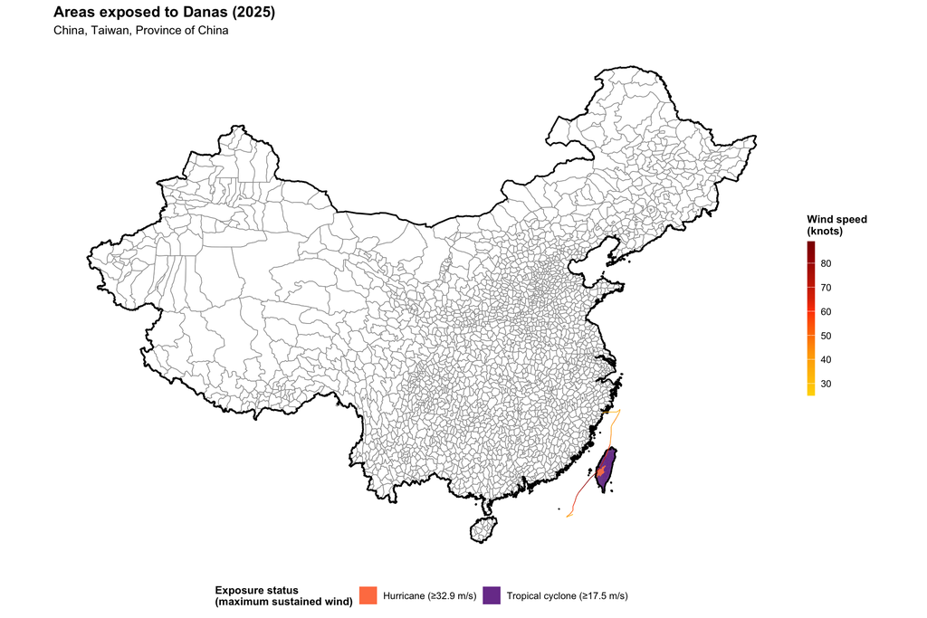

Figure 1: Spatial distribution of exposure

## Characterizing exposed areas

Figure 2 shows the distribution of relative deprivation (measured by population-weighted GRDI, aggregated to ADM2 level) and population for each exposed area, categorized by exposure status.

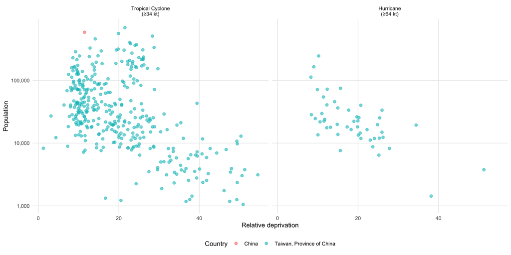

Figure 2: Socioeconomic and population distribution of exposed areas

Furthermore, we list the top areas affected (categorized by exposure status) with the most population:

|  | Area | Country | Population | Relative deprivation |
| --- | --- | --- | --- | --- |
| 1 | Zhonghe District | Taiwan, Province of China | 691,749 | Moderately low |
| 2 | Yuhuanxian | China | 584,577 | Low |
| 3 | Banqiao District | Taiwan, Province of China | 558,412 | Moderately low |
| 4 | Xindian District | Taiwan, Province of China | 507,540 | Moderately low |
| 5 | Sanchong District | Taiwan, Province of China | 458,224 | Low |
| 6 | Taoyuan District | Taiwan, Province of China | 402,794 | Moderately low |
| 7 | Xinzhuang District | Taiwan, Province of China | 384,181 | Moderately low |
| 8 | Tucheng District | Taiwan, Province of China | 370,295 | Moderately low |
| 9 | Zhongli District | Taiwan, Province of China | 362,070 | Moderately low |
| 10 | Shilin District | Taiwan, Province of China | 334,755 | Moderately low |

[output cut: 348 more lines]

|  | Area | Country | Population | Relative deprivation |
| --- | --- | --- | --- | --- |
| 1 | East District | Taiwan, Province of China | 244,908 | Low |
| 2 | Annan | Taiwan, Province of China | 164,603 | Low |
| 3 | West District | Taiwan, Province of China | 112,617 | Low |
| 4 | Minxiong | Taiwan, Province of China | 74,777 | Low |
| 5 | Zhongpu | Taiwan, Province of China | 72,319 | Low |
| 6 | Xiaying | Taiwan, Province of China | 71,231 | Low |
| 7 | Shuishang | Taiwan, Province of China | 54,399 | Low |
| 8 | Chushang | Taiwan, Province of China | 45,717 | Low |
| 9 | Madou | Taiwan, Province of China | 40,690 | Low |
| 10 | Dounan | Taiwan, Province of China | 40,134 | Moderately low |

[output cut: 39 more lines]

```
## *No areas experienced Category 5-force winds.*
```

- Note: GRDI relative deprivation values were classified into quartiles: 0–0.25 (low), 0.25–0.50 (moderately low), 0.50–0.75 (moderately high), 0.75–1.0 (high).